# FCOEX - FCBF-based CoExpression

To start, we will download and clean our datasets of interest.

1 dataset from 10x Genomics downloaded via the data package seurat-data (https://github.com/satijalab/seurat-data)

```r
# devtools::install_github('satijalab/seurat-data')
library('SeuratData')
InstallData("pbmc3k.SeuratData")
```

For starters, we will load the pbmc3k dataset from the SeuratData. This simulates the output of a common Seurat clustering pipeline.

```r
library(Seurat)
library(SeuratData)
data("pbmc3k.final")
```

```r
print(pbmc3k.final)
```

```
## An object of class Seurat
## 13714 features across 2638 samples within 1 assay
## Active assay: RNA (13714 features, 2000 variable features)
##  2 dimensional reductions calculated: pca, umap
```

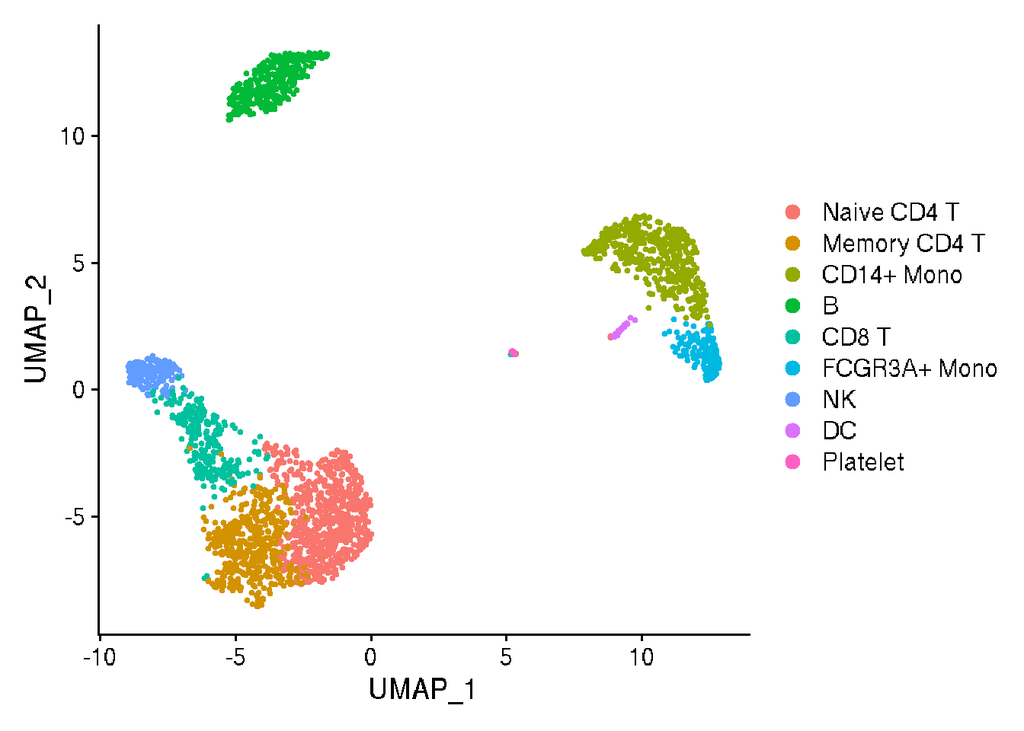

```r
DimPlot(pbmc3k.final)
```

Now that we have our base Seurat object we can perform the fcoex analysis. Let’s time it too.

```r
library(fcoex)
ptm <- proc.time()

exprs <- as.data.frame(GetAssayData(object = pbmc3k.final, slot = "data"))
target <- Idents(pbmc3k.final)


fc <- new_fcoex(data.frame(exprs),target)
```

```
## Created new fcoex object.
```

```r
fc <- discretize(fc)

fc <- find_cbf_modules(fc)
```

```
## Getting SU scores
```

```
## Running FCBF to find module headers
```

```
## Calculating symmetrical uncertainties
```

[output not shown]

[output cut: 78 more lines]

[output not shown]

```
## Calculating adjacency matrix
```

```
## Trimming and getting modules from adjacency matrix
```

```r
fc <- get_nets(fc)

fc <- recluster(fc)
```

```
## Detecting clusters for the following modules:
```

```
## [1] "TYROBP"
```

```
## TYROBP
```

```
## [1] "CD3D"
```

```
## CD3D
```

```
## [1] "S100A9"
```

```
## S100A9
```

```
## [1] "CST3"
```

```
## CST3
```

```
## [1] "HLA-DRB1"
```

```
## HLA-DRB1
```

```
## [1] "AIF1"
```

```
## AIF1
```

```
## [1] "CD79A"
```

```
## CD79A
```

```
## [1] "CST7"
```

```
## CST7
```

```
## [1] "PTPRCAP"
```

```
## PTPRCAP
```

```
## [1] "FCGR3A"
```

```
## FCGR3A
```

```r
time_taken = proc.time() - ptm
```

```r
time_taken
```

```
##    user  system elapsed
## 107.430   2.116 109.643
```

Of note, the current memory handling of the fcoex package is not very good: it takes around 8x the amount of memory of the Seurat object that it processes. For the pbmc3k dataset that is not a problem, but it make it necessary to usea server with more RAM for larger datasets.

```r
save_plots(name = "pbmc3k", fc, force = T, directory = "results/intermediate")
```

```
## Saving available plots.
```

```
##
## $`HLA-DRB1`
```

```
## [[1]]
## PNG
##   2
```

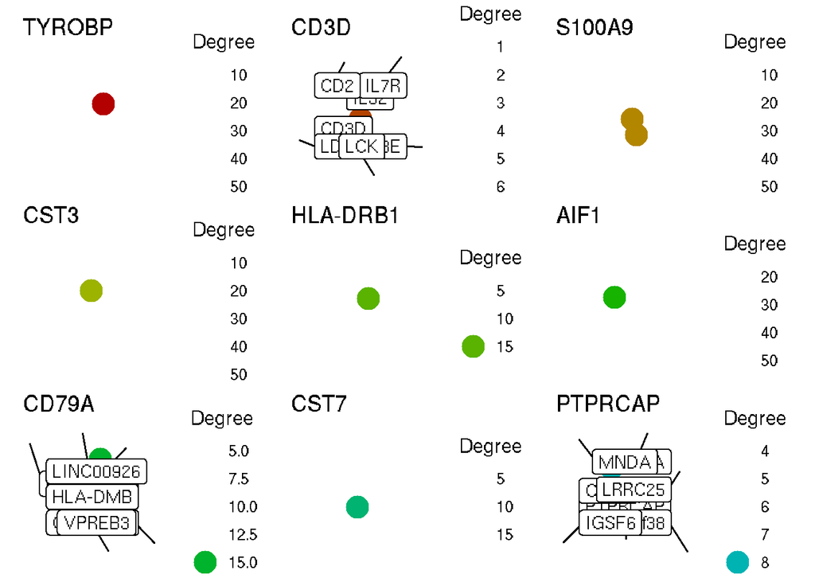

```r
library(patchwork)

coex_module_plots <- show_net(fc)

coex_module_plots[sapply(coex_module_plots, is.null)] <- NULL
wrap_plots(coex_module_plots)
```

Now that we have the modules, we would like to look at the reclusterings.

For that, we will re-integrate the fcoex outputs with the Seurat object.

```r
library(Seurat)
library(ggplot2)
library(dplyr)
# source("../fcoex_themes.R")

module_idents <- data.frame(fc@mod_idents)

colnames(module_idents) <- paste("fcoex", colnames(module_idents), sep="_")

metadata = cbind(pbmc3k.final@meta.data, module_idents)

pbmc3k.final@meta.data <- metadata

print(head(pbmc3k.final@meta.data))
```

```
##                orig.ident nCount_RNA nFeature_RNA seurat_annotations percent.mt
## AAACATACAACCAC     pbmc3k       2419          779       Memory CD4 T  3.0177759
## AAACATTGAGCTAC     pbmc3k       4903         1352                  B  3.7935958
## AAACATTGATCAGC     pbmc3k       3147         1129       Memory CD4 T  0.8897363
## AAACCGTGCTTCCG     pbmc3k       2639          960         CD14+ Mono  1.7430845
## AAACCGTGTATGCG     pbmc3k        980          521                 NK  1.2244898
## AAACGCACTGGTAC     pbmc3k       2163          781       Memory CD4 T  1.6643551
##                RNA_snn_res.0.5 seurat_clusters fcoex_TYROBP fcoex_CD3D
## AAACATACAACCAC               1               1           HN         HP
## AAACATTGAGCTAC               3               3           HN         HN
## AAACATTGATCAGC               1               1           HN         HP
## AAACCGTGCTTCCG               2               2           HP         HN
## AAACCGTGTATGCG               6               6           HN         HN
## AAACGCACTGGTAC               1               1           HN         HP
##                fcoex_S100A9 fcoex_CST3 fcoex_HLA.DRB1 fcoex_AIF1 fcoex_CD79A
## AAACATACAACCAC           HN         HN             HN         HN          HN
## AAACATTGAGCTAC           HN         HN             HP         HN          HP
## AAACATTGATCAGC           HN         HN             HN         HN          HN
## AAACCGTGCTTCCG           HP         HP             HP         HP          HN
## AAACCGTGTATGCG           HN         HN             HN         HN          HN
## AAACGCACTGGTAC           HN         HN             HN         HN          HN
##                fcoex_CST7 fcoex_PTPRCAP fcoex_FCGR3A
## AAACATACAACCAC         HN            HP           HN
## AAACATTGAGCTAC         HN            HP           HN
## AAACATTGATCAGC         HN            HP           HN
## AAACCGTGCTTCCG         HN            HN           HP
## AAACCGTGTATGCG         HP            HN           HN
## AAACGCACTGGTAC         HN            HP           HN
```

Now the modules are inside the metadata of the Seurat object.

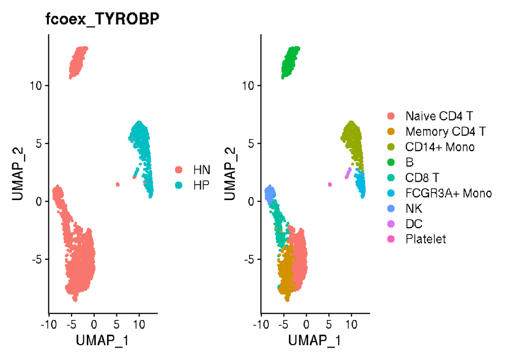

```r
library(patchwork)
p1 <- DimPlot(pbmc3k.final, group.by = "fcoex_TYROBP")
p2 <- DimPlot(pbmc3k.final)

p1 + p2
```

So we see that module one divides the dataset into myeloid (DC + Monocytes) and non-myeloid cells. Cool!

Let’s plot all divisions to make a “cluster forest”.

```r
recluster_theme <- function(){
  theme(axis.title=element_blank(),
        axis.line =element_blank(),
        axis.text=element_blank(),
        axis.ticks=element_blank(),
        legend.position = "none",
        legend.direction = "vertical",
        plot.title = element_text(hjust = 0.5, face = "plain", size = 10))
}

plots <- list()

plots[["base"]] <- DimPlot(pbmc3k.final) + theme( legend.text = element_text(size=8))
for (col_name in colnames(metadata)){
  if (grepl("fcoex", col_name)){
    plots[[col_name]] <- DimPlot(pbmc3k.final, group.by = col_name) + recluster_theme()
  }
  print(col_name)
}
```

```
## [1] "orig.ident"
## [1] "nCount_RNA"
## [1] "nFeature_RNA"
## [1] "seurat_annotations"
## [1] "percent.mt"
## [1] "RNA_snn_res.0.5"
## [1] "seurat_clusters"
## [1] "fcoex_TYROBP"
## [1] "fcoex_CD3D"
## [1] "fcoex_S100A9"
## [1] "fcoex_CST3"
## [1] "fcoex_HLA.DRB1"
## [1] "fcoex_AIF1"
## [1] "fcoex_CD79A"
## [1] "fcoex_CST7"
## [1] "fcoex_PTPRCAP"
## [1] "fcoex_FCGR3A"
```

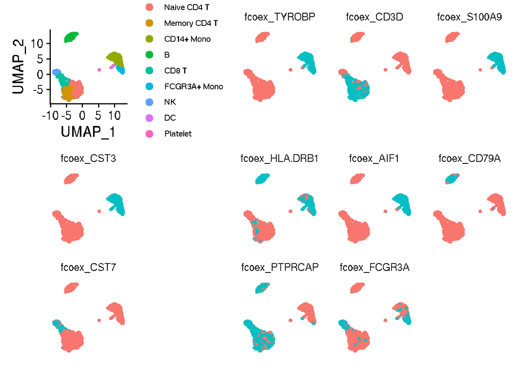

```r
# ggsave("../results/figures/cluster_forest_pbmc3k.pdf", width = 14)
print(wrap_plots(plots))
```

```r
# dev.off()
```

Nice. With the cluster forest we can already get a few new perspectives on the dataset.

Let’s look at a heatmap and look in a different way how the coexpression clusters relate to the original labels.

```r
library(tidyr)
library(scales)

original_clusters <- data.frame(table(Idents(pbmc3k.final)))

metadata <- pbmc3k.final@meta.data

seurat_to_fcoex_proportions = list()
for (identity in levels(Idents(pbmc3k.final))){

  identity_metadata = metadata[metadata["seurat_annotations"] == identity,]

  proportions_for_this_identity = list()
  print(identity)

  for (col_name in colnames(identity_metadata)){
    if (grepl("fcoex", col_name)){

      total_cells = nrow(identity_metadata)
      header_positive_cells = sum(identity_metadata[col_name] == "HP")

      print(total_cells)
      print(header_positive_cells)
      proportions_for_this_identity[[col_name]] <- header_positive_cells/total_cells
    }
  seurat_to_fcoex_proportions[[identity]] <- proportions_for_this_identity
}
}
```

```
## [1] "Naive CD4 T"
## [1] 697
## [1] 0
## [1] 697
## [1] 572
## [1] 697
## [1] 0
## [1] 697
## [1] 0
## [1] 697
## [1] 10
## [1] 697
## [1] 0
## [1] 697
## [1] 0
```

[output cut: 174 more lines]

```r
proportions_df <- data.frame(do.call(rbind, seurat_to_fcoex_proportions))
```

Now let’s plot it. First I’ll write a function to prepare the dataframe in the ggplot2 format.

```r
library(tidyr)
library(tibble)

prepare_proportions_df <-function(proportion_df){
  # Cluster to get factor order ----------
  seurat_distances <- dist(proportions_df)
  fcoex_distances <- dist(t(proportions_df))
  seurat_clustering <- hclust(seurat_distances)
  fcoex_clustering <- hclust(fcoex_distances)

  # Pivot to longer format -----------
  proportions_df$Seurat <- rownames(proportions_df)
  proportions_df_long <- proportions_df %>%
    pivot_longer(cols = !Seurat,names_to="fcoex", values_to="proportion")

  # Adjust types and order of levels of columns in dataframe ----------
  proportions_df_long$proportion <- as.numeric(proportions_df_long$proportion)

  proportions_df_long$Seurat <- factor(proportions_df_long$Seurat, levels = seurat_clustering$labels[seurat_clustering$order])

  proportions_df_long$fcoex <- factor(proportions_df_long$fcoex, levels = fcoex_clustering$labels[fcoex_clustering$order])

  proportions_df_long
}
```

Now plotting it.

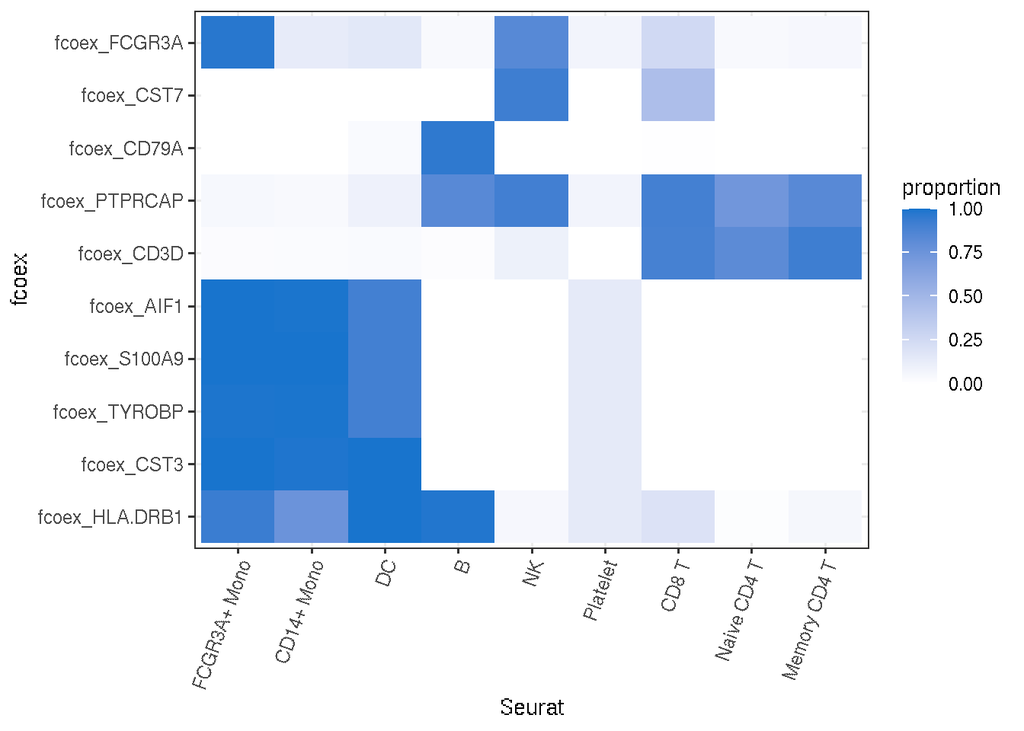

```r
proportions_df %>%
  prepare_proportions_df() %>%
  ggplot(aes_string(x="Seurat", y="fcoex", fill="proportion")) +
    geom_tile() +
    scale_fill_gradient(low = "white", high = "dodgerblue3") +
    theme_bw()+
    theme(axis.text.x = element_text(angle = 70, hjust = 1))
```